# Statistical inference with the GSS data

## Setup

### Load packages

```r
library(ggplot2)
library(dplyr)
library(statsr)
```

### Load data

Make sure your data and R Markdown files are in the same directory. When loaded your data file will be called `gss`. Delete this note when before you submit your work.

```r
load("gss.Rdata")
```

## Part 1: Data

There were two sampling method used in the surveying. The earlier one is “modified probability sample”, introduces the quota element at the block level, used from 1972 to 1974. In 1975-1977, the new method was introduced called " full probability sample", but used for only for one-half of the survey, another half still used the old method for transitioning. From years 1977+, The survey method fully switched to full probability sample.

The data was gathered throughout the US by modified probability sampling and full probability samplling, so it can be generalized to the whole population of the US. On the other hand, the data collected by the survey is observational data, unlike experimental data, we cannot draw any causality from the result of the analysis.

## Part 2: Research question

Does the opinion on abortion with any reasons independence with people in different social class,i.e., do people from one social class have different opinion on abortion topic compared to the people in another class.

Different social class of people tend to show some trend on the way of thinking in many different topic, it would be interesting to try investigating this abortion topic based on the same criteria.

## Part 3: Exploratory data analysis

Select the interested data from the raw data

```r
interested_data <- gss %>%
  select(class,abany)
```

See the summary of the data

```r
summary(interested_data)
```

```
##            class        abany
##  Lower Class  : 3147   Yes :12887
##  Working Class:24458   No  :18920
##  Middle Class :24289   NA's:25254
##  Upper Class  : 1741
##  No Class     :    1
##  NA's         : 3425
```

The “No Class” data will be removed due to having only 1 sample. The missing NA data will also be removed from both columns

```r
interested_data <-
  interested_data[interested_data$class != 'No Class',] %>%
  na.omit()
```

Show the summary of the data again, as well as plotting the bar graph of the data

```r
summary(interested_data)
```

```
##            class       abany
##  Lower Class  : 1653   Yes:12562
##  Working Class:14175   No :18326
##  Middle Class :14054
##  Upper Class  : 1006
##  No Class     :    0
```

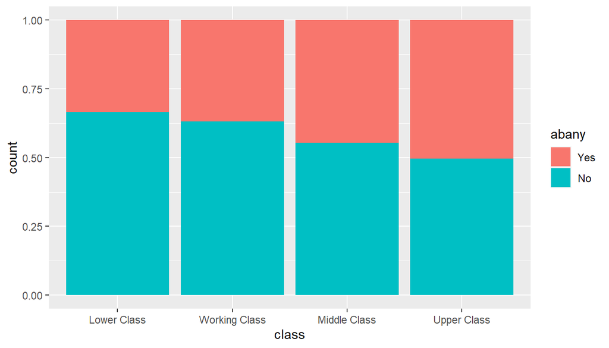

```r
ggplot(data = interested_data,aes(class,fill = abany)) + geom_bar(position = 'fill')
```

According to the bar chart above, there is a visible trend shows that the upper class tend answer the survey with “Yes” (It should be possible for a pregnant woman to obtain a legal abortion for any reason) compared to the lower class with more answer if “No” (It should not be possible for a pregnant woman to obtain a legal abortion for any reason)

## Part 4: Inference

Step 1: State hypotheses

H0: The opinion on abortion is independent to the social class HA: The opinion on abortion is not independent to the social class

Step 2: Check conditions

1. Independence
- The sampling method is random
- The sample is less than 10% of the population
- Each case contribute to only one cell in the table
2. Sample size
- Each scenerio have at least 5 expected cases

Step 3: State the method(s) to be used and why and how Since we want to know whether one variable is independent to another variable or not, Chi-Square Test of Independence will be used to conduct an analysis. By comparing observed values and the expected values, if sum of the different between observed and expected values is high, it is more likely that the variable is dependent to each other.

Step 4: Perform inference

```r
inference(y= abany, x = as.factor(class),
          data = interested_data,
          type = 'ht',
          statistic = 'proportion',
          success = 'Yes',
          method = 'theoretical',
          null = 0,
          )
```

```
## Response variable: categorical (2 levels)
## Explanatory variable: categorical (5 levels)
## Observed:
##                y
## x                Yes   No
##   Lower Class    551 1102
##   Working Class 5230 8945
##   Middle Class  6274 7780
##   Upper Class    507  499
##
## Expected:
##                y
## x                     Yes        No
##   Lower Class    672.2671  980.7329
##   Working Class 5764.9038 8410.0962
##   Middle Class  5715.6937 8338.3063
##   Upper Class    409.1353  596.8647
##
## H0: as.factor and abany are independent
##  H0: class and abany are independent
## HA: as.factor and abany are dependent
##  HA: class and abany are dependent
## chi_sq = 251.8953, df = 3, p_value = 0
```

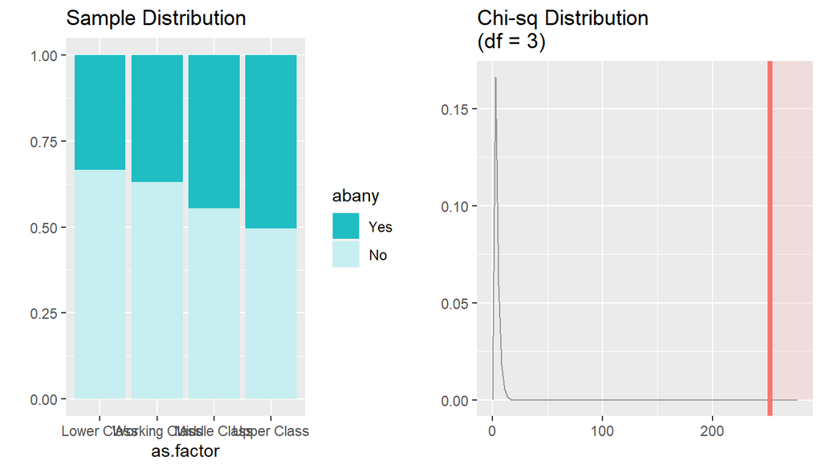

Step 5: Interpret results

With very high chi-squared value resulting in very low p-value, we can say that it is very unlikely that the difference of the proportion of the opinion on abortion topic in each class is due to chance, and thus we reject the null hypothesis and conclude that the opinion on abortion is dependent to the social class.